# gpuR

Bruno Hanzen

26 mars 2017

## R and parallelism

I have just passed my “Datascience Specialization” on Coursera (https://www.coursera.org/specializations/jhu-data-science). This specialization uses R as the programming language for all assignments. The last step is the “Capstone Project” which involved some Natural Language Processing, with 550 MB sample texts. So, during the last 2 months, I had ample opportunity to wait while my PC was working all those MB. As you may know, R (like Python) is intrinsically mono-threaded, meaning that it can only use 1 “core” on our marvellous multi-cores modern machines (unless you can use specific multi-threaded libraries, generally written in C). On my quad-core machine, this left 3 cores to run Solitaire while I was waiting. Now that I have submitted the project, I have some time available explore other subjects. As I have a long-time interest in GPUs, I have had a look at what R can do in the domain.

## GPU programming

Our graphics card are based on powerful parallel computation engines, called GPUs, for “Graphical Processing Units”, as opposed to CPUs (Central Processing Units). Some clever programmers quickly realised that the GPU processing power could be used for other tasks than just driving the display. People started to tinker with those grapics cards,and 2 standards emerged: CUDA, which is NVIDIA proprietary (and limited to their own GPUs), and OpenCL, which supports a wide set of GPUs from various vendors. You can find some information about an early system (2008-2009) here: https://en.wikipedia.org/wiki/Fastra_II.

As my PC is based on an AMD A10 processor (which integrates 4 CPU cores and a GPU on the same chip), I chose for the OpenCl path.

## gpuR

Linear algebra is widely used (although most of the time “under the hood”), so improving the performance of such operations can be useful.

The package basically implements 2 new object classes: gpuMatrix and gpuVector (the names are self-explaining) and most of the basic linear algebra operators (products, linear equation resolution, …). Its usage is quite straightforward.

### gpuR installation

You first need to download the package from the CRAN. It comes under the form of a source code package, meaning some compilation is necessary before using it.

The “install” document of the CRAN is not up to date. You’d better go directly to the github wiki (https://github.com/cdeterman/gpuR/wiki) and get the correct information.

#### Pre requisites

I did not “RTFM”, and lost some time figuring out what did not work. So, be more clever…

- OpenCL SDK: GPU-vendor specific software, that implements OpenCL (see it as some kind of driver). If not already installed, you’ll find them on your vendor’s web site. You’ll find convenient instructions in this link: https://github.com/cdeterman/gpuR/wiki/Installing-OpenCL
- Rtools: https://cran.r-project.org/bin/windows/Rtools/. Although it is not documented, I had to install it in the root of my C: drive. That’s something I do not like, but the alternative was to edit the installation scripts of gpuR. I chose the safe and lazy option. By the way, it seems that many packages assume that this is the standard RTools location.

#### Manual actions

- Set some environment variables (OPENCL_INC, OPENCL_LIB32, OPENCL_LIB64), respectively to the directories containing the headers and the 32- and 64-bits libraries of the SDK.

After this, you can just install the package with the usual command

## Is it worth doing?

Nothing like a test to make sure that it works and brings some benefits. I have written a small test program, that generate an arbitrary size random matrix, inverts it with and without the GPU.

```r
library("gpuR")
compareinv <- function(dim){
  # create creates a random matrix of size dim x dim and inverts it
  # with gpu- and cpu-based methods. Returns execution times.
  set.seed(123)
  gpuA <- gpuMatrix(rnorm(dim*dim), nrow=dim, ncol=dim)
  # Create identity matrix
  E <-gpuMatrix(identity_matrix(dim)[], nrow=dim, ncol=dim)
  # Invert A by solving the equation AX=E
  gpuT<-system.time(C<-solve(gpuA, E))
  # copy the content of the gpu Matrix to a plain R matrix
  mA <- gpuA[]
  # invert with the built-in R function
  cpuT<-system.time(D<-solve(mA))
  times <- data.frame(size=dim, cpu.user=cpuT[["user.self"]], cpu.system=cpuT[["sys.self"]]
                      , cpu.elapsed=cpuT[["elapsed"]], gpu.user=gpuT[["user.self"]]
                      , gpu.system=gpuT[["sys.self"]], gpu.elapsed=gpuT[["elapsed"]],
                      row.names=NULL)
  return(times)
  times
}
# initialise the data frame
results <- data.frame(size=numeric(0), cpu.user=numeric(0),
                      cpu.system=numeric(0), cpu.elapsed=numeric(0),
                      gpu.user=numeric(0), gpu.system=numeric(0),
                      gpu.elapsed=numeric(0),row.names=NULL)
for (i in seq(from=300, to= 2500, by=100))
{
  result <-compareinv(i)
  results <- rbind(results, result)
}
```

## Analysing the results

### Elapsed time:

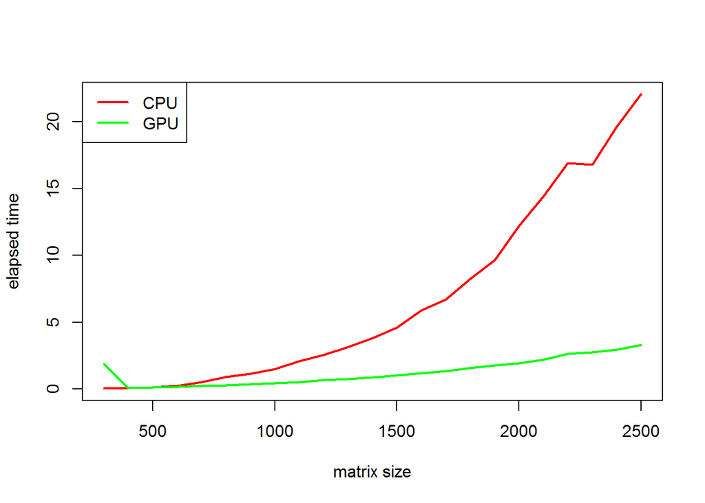

```r
# plot the elapsed time
plot(x=results$size, y=results$cpu.elapsed, type="l", col="red", lwd=2, xlab="matrix size", ylab="elapsed time")
lines(x=results$size, y=results$gpu.elapsed, col="green", lwd=2)
legend("topleft",legend=c("CPU", "GPU"), col=c("red", "green"), lty=1, lwd=2)
```

We see that, except for small matrices (less than 500 x 500), the GPU inversion is significantly faster. For the smaller matrices, the overhead (setting the environment, moving data between CPU and GPU) is significant and is not compensated by the faster execution. The first execution event takes more time, probably due to some initialisation of the environment.

### User time:

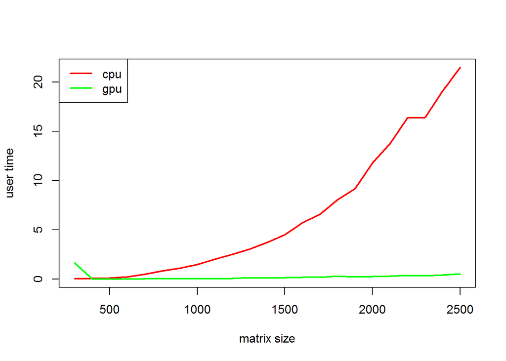

```r
# plot the user time
plot(x=results$size, y=results$cpu.user, type="l", col="red", lwd=2, xlab="matrix size", ylab="user time")
lines(x=results$size, y=results$gpu.user, col="green", lwd=2)
legend("topleft",legend=c("cpu", "gpu"), col=c("red", "green"), lty=1, lwd=2)
```

The “user time” of the GPU method is nearly flat, and much lower than its elapsed time. This shows that the workload is transferred from the CPU to the GPU.

### System time

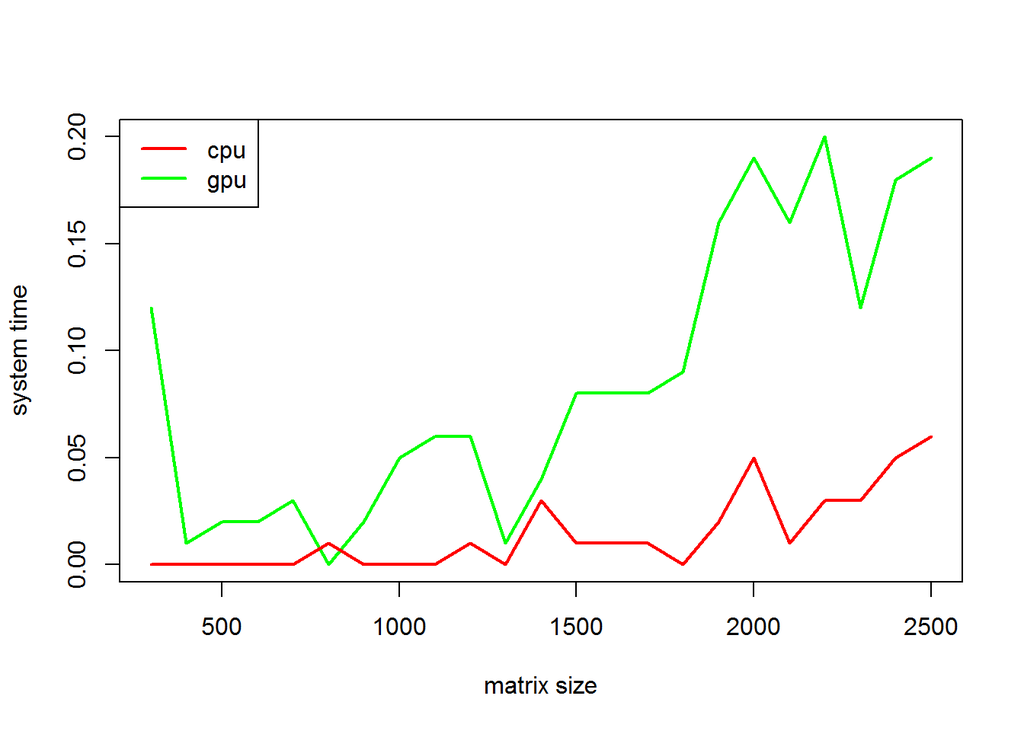

```r
# plot the user time
plot(x=results$size, y=results$gpu.system, type="l", col="green", lwd=2, xlab="matrix size", ylab="system time")
lines(x=results$size, y=results$cpu.system, col="red", lwd=2)
legend("topleft",legend=c("cpu", "gpu"), col=c("red", "green"), lty=1, lwd=2)
```

The GPU method generates more system activity, which covers “under the hood” activities like communication between CPU and GPU.

### Conclusion

gpuR brings some additional complexity. Most of it lies in setting up a working openCL environment on your system, and it is a one-shot activity.

The complexity that gpuR adds to your code is nearly insignificant.

My test show that, on a moderately powerful GPU, you can increase the performance above 500 x 500 matrices. The bigger the objects, the bigger the benefit.

So, if you deal with large linear algebra object, go for it. The cost is low, and the benefits can be big.